# The steady state

We start with a simple **reversible** model with rate constants $k_1$ for the forward and $k_2$ for the reverse reaction.  
$S_1 \rightleftharpoons ^{k_1}_{k_2} S_2 $  
Then we extend this model to an open system by adding a **source** reaction with rate $k_0$ and a **sink** reaction with a rate $k_3$.  
$X_0 \rightarrow ^{k_0} S_1 \rightleftharpoons ^{k_1}_{k_2} S_2 \rightarrow^{k_3} X_1 $  
**Assumptions**  
1.Mass-action kinetics  
2.Source and sink reactions are irreversible and $X_0,X_1$ are boundary species.  
To make it easy to solve :  
1.Set the reverse rate constant $k_2$ to 0.  
2.Set initial concentrations of $S_1,S_2$ to 0 in order to derive a time course solution. To follow the example better we rename $k_0$ to $v_1$, $k_1$ to $v_2$, $k_2$ is ignored and $k_3$ to $v_3$.  
$X_0 \rightarrow^{v_1} S_1 \rightarrow^{v_2} S_2 \rightarrow^{v_3} X_1 $  
Using **matematica** calculate the solution for the system.  
$S_1(t) = v_1 \frac{1 - e^{-v_2t}}{v_2}$  
$S_2(t) = v_1 \frac{v_2(1 - e^{-v_3t})+v_3(e^{-v_2t}-1)}{v_3(v_2-v_3)}$  
What if the time tends to infinity? Recap $e = 2.718$, so $e^{-v_2t}$ will be very small and $1 - e^{-v_2t}$ tends to 1, so that we could approximate  
$S_1(\infty) = \frac{v_1}{v_2}$  
And $v_2(1 - e^{-v_3t})$ can be approximated to $v_2$, as well as $v_3(e^{-v_2t}-1)$ to $-v_3$  
$S_2(\infty) = \frac{v_1(v_2-v_3)}{v_3(v_2-v_3)} = \frac{v_1}{v_3}$  
Differential equations for that system are  
$\frac{dS_1}{dt} = v_1 - v_2 \cdot [S_1]$  
$\frac{dS_2}{dt} = v_2 \cdot [S_1] - v_3 \cdot [S_2]$  
Set rates of changes to zero.  
$0 = v_1 - v_2 \cdot [S_1] \Leftrightarrow [S_1] = \frac{v_1}{v_2}$  
$0 = v_2 \cdot [S_1] - v_3 \cdot [S_2] \Leftrightarrow [S_2] = \frac{v_2 \cdot [S_1]}{v_3}=\frac{\frac{v_1}{v_2} \cdot v_2}{v_3} = \frac{v_1}{v_3}$

Conclusion : a reaction rate through each of the three reaction steps is $v_1$. The system displays a continious flow of mass from source to sink . This can only continue undisturbed as long as the source material $X_0$ never runs out.

### Simulation of the steady state

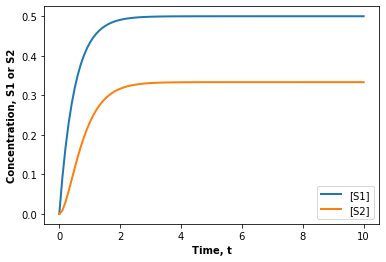

```python
import tellurium as te
#compute reaching the steady state
r = te.loada ( '''
    J0: $Xo -> S1; v1;
    J1: S1 -> S2; v2*S1;
    J2: S2 -> $X1; v3*S2;
    // set up model initial conditions
    Xo = 1; X1 = 0;
    v1 = 1; v2 = 2; v3 = 3;
''')
r.simulate(0,10,100);
r.plot(xtitle = "Time, t", ytitle = "Concentration, S1 or S2");
```

Load a model.

### Evaluation of the steady state with Tellurium p.ss.eval

```python
r = te.loada ( '''
    J0: $Xo -> S1; v1;
    J1: S1 -> S2; v2*S1;
    J2: S2 -> $X1; v3*S2;
    // set up model initial conditions
    Xo = 1; X1 = 0;
    v1 = 1; v2 = 2; v3 = 3;
''')
```

```python
r.steadyState()
print(r.S1, "  ", r.S2)
```

```
0.5    0.3333333333333333
```

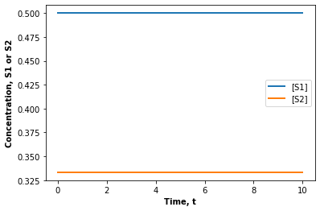

```python
r.simulate(0,10,100);
r.plot(xtitle = "Time, t", ytitle = "Concentration, S1 or S2");
```

### Graphical illustration of the steady state

$X_0 \rightarrow^{v_1} S_1 \rightarrow^{v_2} X_1 $  
First-order mass balance kinetics  
$v_1 = k_1[X_0]$  
$v_2 = k_2[S_1]$  
$k_1,k_2$ first-order reaction rate constants  
Model is a single differential equation :  
$\frac{dS_1}{dt} = v_1 - v_2 = k_1X_0 - k_2S_1$  
Set rate of change to 0 and solve to the steady state concentration of $S_1$  
$S_1 = \frac{k_1X_0}{k_2}$  
Determine the pathway flux **J** by inserting the steady state concentration of $S_1$ into the rate law  
$J = v_1 = v_2 = k_2 \cdot [S_1]= k_2 \cdot \frac{k_1X_0}{k_2} = k_1X_0$

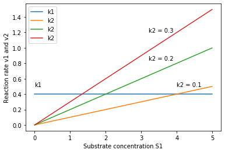

```python
import numpy as np
import matplotlib.pyplot as plt

s1_list = [c for c in np.arange(0,5,0.01)]
k1 = 0.4
x0 = 1
v1 = [k1*x0 for s1 in s1_list]
v2_1 = [0.1*s1 for s1 in s1_list ]
v2_2 = [0.2*s1 for s1 in s1_list ]
v2_3 = [0.3*s1 for s1 in s1_list ]
#plot v1
plt.plot(s1_list, v1, label = "k1")
plt.ylabel('Reaction rate v1 and v2')
plt.xlabel('Substrate concentration S1')
plt.plot(s1_list,v2_1, label = "k2")
plt.plot(s1_list,v2_2, label = "k2")
plt.plot(s1_list,v2_3, label = "k2")
plt.legend()
plt.text(0.0,0.5,'k1')
plt.text(3.2,1.2,'k2 = 0.3')
plt.text(3.2,0.84,'k2 = 0.2')
plt.text(4,0.5,'k2 = 0.1')
plt.show()
```

Reaction rates were plotted as a function of the floating species concentration, $S_1$. The intersection of two lines marks the steady state point, where $v_1 = v_2$.  
Observation : first step of the reaction is always constant(no product inhibition), and if the reaction rate of the second reaction is high, it is enough to reach a steady state with less substrate $S_1$.  
Second line has a slope equal to $k_2$. Intersections indicate when both reaction rates are equal, so $\frac{dS_1}{dt}= 0$

## Effect of perturbations on the steady state of a system

### Perturbing floating species

$X_0 \rightarrow^{v_1} S_1 \rightarrow^{v_2} X_1 $  
First-order mass balance kinetics  
$v_1 = k_1[X_0]$  
$v_2 = k_2[S_1]$  
$k_1,k_2$ first-order reaction rate constants.

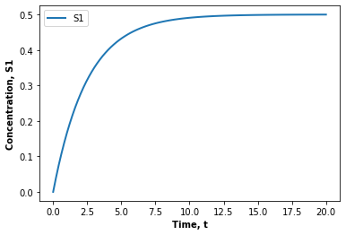

```python
#Allow a system to reach a steady state
per_model = te.loada('''
$Xo -> S1; k1*Xo;
S1 -> $X1; k2*S1;

k1 = 0.2; k2 = 0.4;
Xo = 1; S1 = 0.0;
''')
sim_per_model = per_model.simulate(0,20,100,["time","S1"])
per_model.plot(xtitle = "Time, t", ytitle = "Concentration, S1");
```

As we see, the steady state concentration of $S_1$ is 0.5. Inject 0.35 $S_1$ at $t = 20$

```python
per_model.steadyState()
print(per_model.S1)
```

```
0.5
```

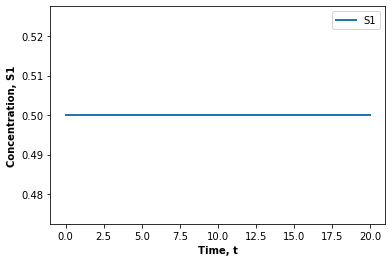

```python
before_pert_model = per_model.simulate(0,20,100,["time","S1"])
per_model.plot(xtitle = "Time, t", ytitle = "Concentration, S1");
```

Now we can consider applying perturbations on the steady state system.

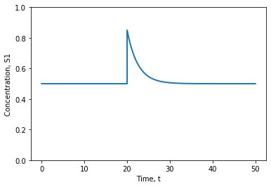

```python
#perturb the concentration of S1 by 0.35 units
per_model.S1 = per_model.S1 + 0.35
#continue simulation
after_pert_model = per_model.simulate(20,50,100,["time","S1"])
#merge plots
result = np.vstack((before_pert_model, after_pert_model))
te.plotArray(result, xlabel = "Time, t", ylabel = "Concentration, S1", ylim = (0,1) );
```

To Do : multiple perturbations Perturbations in the conserved cycle Stable/unstable systems

## Computing the steady state

Two approaches:

1. Run a time course simulation for a long period, that traectories of concentrations reaches the steady state
2. Set models differential equations to zero  
   $f(x, p) = 0$

#### Newton-Raphson method

Example: compute root of $f(x) = x^2 - a, f(x)= 0 \Leftrightarrow x^2 - a = 0$  
Newton showed, that if g ("guess") is an approximation to the root of $f(x)$, that $g - \frac{f(g)}{f'(g)}$ is better approximation, where $f'(g)$ is derivative.  
$f(x) = x^2 - a$  
First derivative is $2x$  
Newton-Raphson says : given a guess g, a better guess for root is  
$g - \frac{g^2 - a}{2g}$  
Geometrical explanation

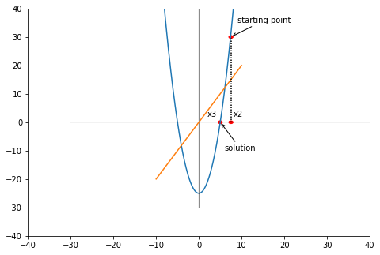

```python
fig = plt.figure()
ax = fig.add_axes([0,0,1,1])
xy_0 = np.arange(-30.0,80.0, 0.01)


x = np.arange(-10.0, 10.0, 0.01)
y = [x**2 - 25 for x in x]

ax.plot(x, y)
ax.plot(xy_0,[0 for x in xy_0], linewidth = 0.5, color = 'black')
ax.plot([0 for x in xy_0],xy_0, linewidth = 0.5, color = 'black')
derivative = [2*x for x in x]
ax.plot(x, derivative)
solution = plt.Circle((5,0),radius = 0.5, color = 'red')
first_guess = plt.Circle((7.5,30),radius = 0.5, color = 'red')
x_2 = plt.Circle((7.5,0),radius = 0.5, color = 'red')
ax.plot([7.5 for x in np.arange(0,30,0.1)] , np.arange(0,30,0.1),linestyle = (0, (1,1)), color = 'black' )
#add circles
ax.add_artist(solution)
ax.add_artist(first_guess)
ax.add_artist(x_2)
#add comments
plt.annotate('solution', xy=(5, 0), xytext=(6, - 10.0),
             arrowprops = { "arrowstyle": '->'})
plt.annotate('starting point', xy=(7.5, 30), xytext=(9, 35),
             arrowprops = { "arrowstyle": '->'})
plt.text(2,2,"x3")
plt.text(8,2,"x2")
plt.xlim(-40,40)
plt.ylim(-40,40)
plt.show()
```

### Implementation of the algorithm

```python
epsilon = 0.01
y = 25.0
#guess = y/2.0
guess = 15.0
counter = 1
#while difference between the real solution and guess is big
while abs(guess*guess - y) >= epsilon:
    guess = guess - (guess**2 - y)/(2*guess)
    print('Iteration ', counter, ' : Square root of', y, " is appr. ", guess)
    counter+= 1
```

```
Iteration  1  : Square root of 25.0  is appr.  8.333333333333332
Iteration  2  : Square root of 25.0  is appr.  5.666666666666666
Iteration  3  : Square root of 25.0  is appr.  5.03921568627451
Iteration  4  : Square root of 25.0  is appr.  5.000152590218967
```

#### Extension to a matrix form

Normal form  
$x_{k+1} = x_k - \frac{f(x_k)}{f'(x_k}$  
Extension for matrix  
$x_{k+1} = x_k - [\frac{\partial f(x)}{\partial x}]^{-1} f(x_k)$  
If $m$ is a number of state variables (floating species in model), then $x_k$ is a $m$ dimensional vector with guessed solutions (species concentrations),  
$f(x_k)$ is a vector, containing $f(x)$ for all $x_k$ ($m$ rates of change) $[\frac{\partial f(x)}{\partial x}]$ is $m\times m$ **invertible** Jacobian matrix

### Solving the Steady State for a simple pathway

$X_0 \rightarrow^{v_1} S_1 \rightarrow^{v_2} S_2 \rightarrow^{v_3} X_1$  
Differential equations  
$\frac{dS_1}{dt} = v_1 - v_2 = (k_1X_0 - k_2S_1) - (k_3S_1 - k_4S_2)$  
$\frac{dS_2}{dt} = v_2 - v_3 = (k_3S_1 - k_4S_2) - (k_5S_2 - k_6X_1)$

#### Parameters

| Parameter | Value |
| --- | --- |
| $k_1$ | 3.4 |
| $k_2$ | 0.2 |
| $k_3$ | 2.3 |
| $k_4$ | 0.56 |
| $k_5$ | 5.6 |
| $k_6$ | 0.12 |
| $X_0$ | 10 |
| $X_1$ | 0.0 |

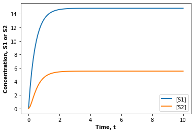

```python
nr_alg_model = te.loada ( '''
    J0: $Xo -> S1; k1*Xo - k2*S1;
    J1: S1 -> S2; k3*S1 - k4*S2;
    J2: S2 -> $X1; k5*S2 - k6*X1;
    // set up model initial conditions
    k1 = 3.4; k2 = 0.2; k3 = 2.3; k4 = 0.56; k5 = 5.6; k6 = 0.12;
    Xo = 10.0; X1 = 0.0; S1 = 0.0; S2 = 0.0;
''')
nr_alg_model.simulate(0,10,100);
nr_alg_model.plot(xtitle = "Time, t", ytitle = "Concentration, S1 or S2");
```

```python
import sympy as sp
# constants
k1 = 3.4
k2 = 0.2
k3 = 2.3
k4 = 0.56
k5 = 5.6
k6 = 0.12
X0 = 10
X1 = 0.0
# equations
# x_k = [s1
#       s2]
S1 = 1
S2 = 1
guess = np.array([[S1],[S2]])
print('Initial guess S1: ', S1, ', S2: ', S2)
def dS1(X0, S1, S2):
    solution = (k1*X0 - k2*S1) - (k3*S1 - k4*S2)
    return solution

def dS2(X1, S1, S2):
    solution = (k3*S1 - k4*S2) - (k5*S2 - k6*X1)
    return solution
counter = 0
epsilon = 0.01
print("Initial dS1/dt ", dS1(X0,guess[0,0], guess[1,0]))
print("dS2/dt ", dS2(guess[0,0],guess[1,0],X1))
while abs(dS1(X0,guess[0,0], guess[1,0])) > epsilon and abs(dS2(guess[0,0],guess[1,0],X1)) > epsilon:
    x_k = np.array([[dS1(X0, guess[0,0],guess[1,0])],[dS2(X1, guess[0,0],guess[1,0])]])
    jakob_matrix = np.array([[-k2 - k3, -k4],
                        [k3, - k4 - k5]])
    inv_jakob_matrix = np.linalg.inv(jakob_matrix)
    guess = np.subtract(guess, np.multiply(inv_jakob_matrix, x_k))
    counter += 1
    print('Iteration : ', counter, ' S1 ', guess[0,0], ' S2 ', guess[1,0], ' dS1/dt ', x_k[0,0], ' dS2/dt ', x_k[1,0])
```

```
Initial guess S1:  1 , S2:  1
Initial dS1/dt  32.059999999999995
dS2/dt  2.42
Iteration :  1  S1  12.834228187919463  S2  0.4680009587727709  dS1/dt  32.059999999999995  dS2/dt  -3.86
Iteration :  2  S1  13.637637944236747  S2  4.13904779064006  dS1/dt  2.176510067114098  dS2/dt  26.635838926174493
Iteration :  3  S1  14.458493344365346  S2  4.948076771178412  dS1/dt  2.2237719021665683  dS2/dt  5.870032881401748
Iteration :  4  S1  14.689083476593938  S2  5.330452016722332  dS1/dt  0.6246896309465484  dS2/dt  2.774381781581276
Iteration :  5  S1  14.785922027489116  S2  5.461288990491503  dS1/dt  0.26234443787966555  dS2/dt  0.9493075731564886
Iteration :  6  S1  14.820441639082304  S2  5.51174351518792  dS1/dt  0.0935167659524545  dS2/dt  0.366080481797308
Iteration :  7  S1  14.83353543031701  S2  5.530305005334309  dS1/dt  0.035472270799473904  dS2/dt  0.1346757163317136
Iteration :  8  S1  14.83838289673116  S2  5.537258571417751  dS1/dt  0.013132227194695645  dS2/dt  0.05045265686977274
```